# Most of the R u need 4 this course

Ralf Martin

08/10/2021

In this document I am going through a couple of commands and use cases using R. This follows more or less Exercise 2.2.

In terms of R, this covers most of what you need for the graded part of this course. It also largely covers what would be needed for the group coursework (although you are of course welcome to go beyond).

I hope you will appreciate that these are actually only a few commands and concepts. R can be confusing because it can do so many things. But think of it like learning a language, which means:

- It takes a while to get used to
- You have to practice regularly
- You cannot expect to read and write abstract poetry or a novel that will be nominated for the Nobel Prize after a week
- However, you should be able to use a couple of words and expressions right away and go and use this as much as possible while discovering new words and expressions here and there.
- Also: you will be able to use those expressions successfully without necessarily understanding the grammatical logic or etymology behind them. But as you keep on at you might find out these things at some point.

What I am trying to do in this document and in the course overall is to provide you a couple of R words and expressions for you to play around with. Playing means:

- you try the same commands with different data (e.g. the data for your group project)
- you try change things here and there (change how a figure looks slighlty, change how a variable is defined)
- you think of something you might want to do (construct a new variable based on exisitng ones, create a figure, combine and clean some unusual data). You see if you can do it by consulting the help functions and the internet. If you don’t manage you can ask your teachers (us) for help.

So what are the basic expressions in R that you want to start your journey to Rland with; i.e. the equivalent of ordering a coffee and a croissant?

# Getting data

You will want to start with getting data. Let’s look at the data from Exercise 2.2 however it will be very similar if you were to use some other data.

```r
covid=read.csv("https://raw.githubusercontent.com/nytimes/covid-19-data/master/us-states.csv")
```

i.e. you use the `read.csv` command to load the dataset into the memory as a data frame

# Data manipulation and cleaning

Data comes rarely in a way such that you can start analysis right away. So you need to know some commands that help you with things like removing some observations or creating new variables.

## Create new variables from existing and filter data

```r
library(dplyr)
# keep the data point for  the end of July 2020
covid_july=covid %>% filter(as.character(date)=="2020-07-31")


# create various ratios
covid_july = covid_july %>%
                 mutate(deathsOcases=deaths/cases,
                 deaths_sh=deaths/sum(deaths),
                 cases_sh=cases/sum(cases))
```

Part of data manipulation is that you look at your data. We already saw the summary command

```r
covid_july %>% summary()
```

```
##      date              state                fips           cases
##  Length:55          Length:55          Min.   : 1.00   Min.   :    42
##  Class :character   Class :character   1st Qu.:17.50   1st Qu.: 13457
##  Mode  :character   Mode  :character   Median :31.00   Median : 46948
##                                        Mean   :32.04   Mean   : 83121
##                                        3rd Qu.:45.50   3rd Qu.: 90956
##                                        Max.   :78.00   Max.   :502273
##      deaths         deathsOcases        deaths_sh           cases_sh
##  Min.   :    2.0   Min.   :0.004528   Min.   :0.000013   Min.   :9.190e-06
##  1st Qu.:  263.5   1st Qu.:0.014963   1st Qu.:0.001713   1st Qu.:2.944e-03
##  Median :  943.0   Median :0.021222   Median :0.006129   Median :1.027e-02
##  Mean   : 2797.5   Mean   :0.029697   Mean   :0.018182   Mean   :1.818e-02
##  3rd Qu.: 3491.0   3rd Qu.:0.039424   3rd Qu.:0.022689   3rd Qu.:1.990e-02
##  Max.   :32372.0   Max.   :0.088978   Max.   :0.210396   Max.   :1.099e-01
```

With that we see that the maximum death rate is nearly 9%. But which state was that in? You can use the filter command again to work it out:

```r
covid_july %>% filter(deathsOcases>0.088)
```

```
##         date       state fips cases deaths deathsOcases  deaths_sh   cases_sh
## 1 2020-07-31 Connecticut    9 49810   4432   0.08897812 0.02880503 0.01089536
```

```r
covid_july=covid_july %>% arrange(deathsOcases)
covid_july=covid_july %>% arrange(-deathsOcases)
```

## Compute summary statistics or aggregate data

For instance work out the total death and case figures from state level ones

```r
usdaily=covid %>% group_by(date) %>%
        summarise(deaths=sum(deaths),
                  cases=sum(cases))

head(usdaily)
```

```
## # A tibble: 6 x 3
##   date       deaths cases
##   <chr>       <int> <int>
## 1 2020-01-21      0     1
## 2 2020-01-22      0     1
## 3 2020-01-23      0     1
## 4 2020-01-24      0     2
## 5 2020-01-25      0     3
## 6 2020-01-26      0     5
```

What if you want something other than the sum of a variable? There loads of other functions. You can start by using help function (by typing `?summarise()` in the console) or read about the summarise command online (just google `dplyr summarise` which would lead you for instance to [this](https://dplyr.tidyverse.org/reference/summarise.html))

## Combining data

First you need another dataframe to combine

```r
pop=read.csv("https://mondpanther.github.io/datastorieshub/data/populationdata.csv")
```

You can use the `merge` command which is an older command. A newer version of the same idea are the join commands (As I mentioned: the difficulty with R is that there are often several different commands that do more or less the same)

```r
covid_julyb=covid_july %>% left_join(pop,by="state")
```

# Data visualisation

Let’s run through the ggplot command once more…..as I said: it’s a bit of swiss army knife of plotting

## Scatter plot

However first: with more data comes more data manipulation; e.g. cases per capita….

```r
covid_julyb=covid_julyb %>% mutate(casesOpop000=cases/pop*1000)
```

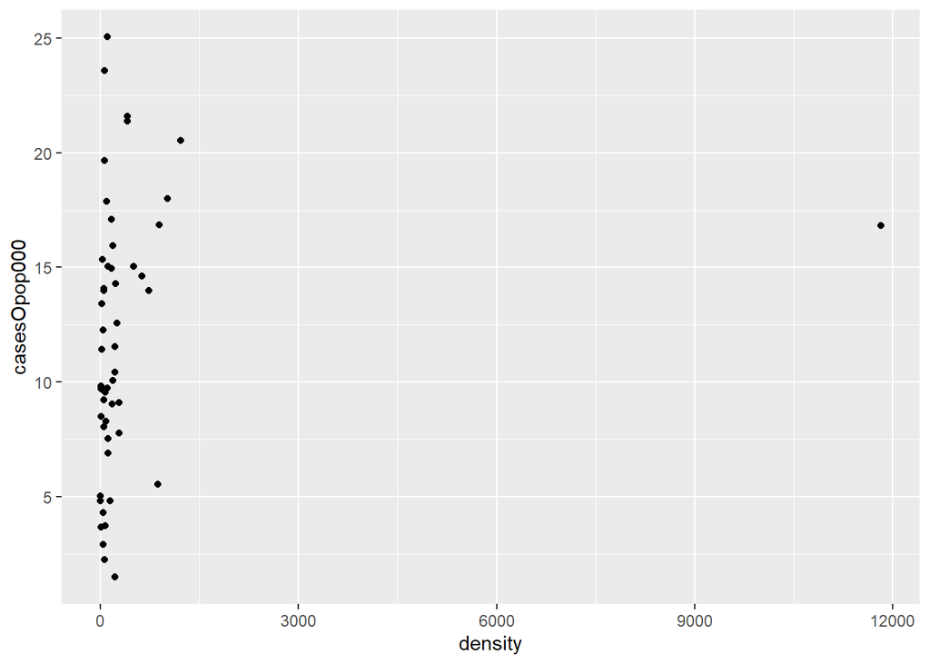

```r
library(ggplot2)


p=ggplot(covid_julyb, aes(x=density, y=casesOpop000 ))+
       geom_point()
p
```

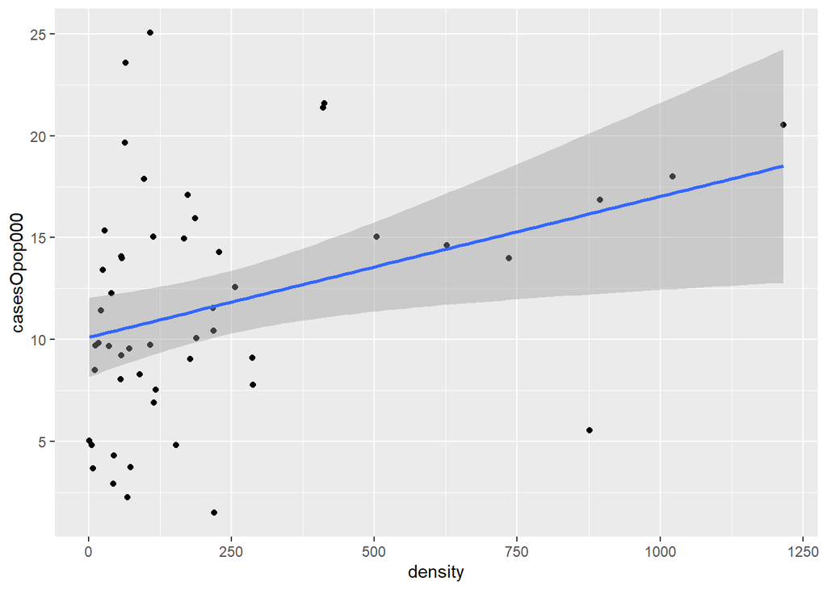

```r
p=p + geom_smooth(method=lm)


# Dropping the outlier

ggplot(covid_julyb %>% filter(density<6000), aes(x=density, y=casesOpop000 ))+
      geom_point() +
      geom_smooth(method=lm)
```

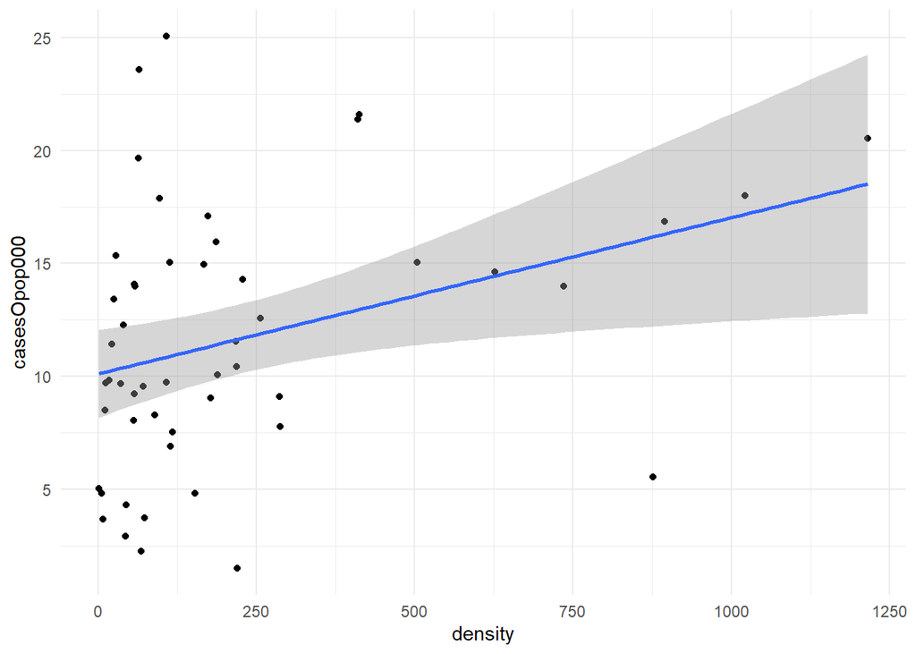

```r
# Less clutter

ggplot(covid_julyb %>% filter(density<6000), aes(x=density, y=casesOpop000 ))+
      geom_point() +
      geom_smooth(method=lm)+theme_minimal()
```

# Fitting an econometric model

The simplest case is the linear model which we can fit using the OLS algorithm. The `lm()` command is your tool for that.

```r
summary(lm(casesOpop000~density,covid_julyb  %>% filter(density<6000) ))
```

```
##
## Call:
## lm(formula = casesOpop000 ~ density, data = covid_julyb %>% filter(density <
##     6000))
##
## Residuals:
##      Min       1Q   Median       3Q      Max
## -10.6365  -3.1810  -0.4811   3.3123  14.2090
##
## Coefficients:
##              Estimate Std. Error t value Pr(>|t|)
## (Intercept) 10.103760   0.970901  10.407 5.27e-14 ***
## density      0.006921   0.002751   2.516   0.0152 *
## ---
## Signif. codes:  0 '***' 0.001 '**' 0.01 '*' 0.05 '.' 0.1 ' ' 1
##
## Residual standard error: 5.466 on 49 degrees of freedom
## Multiple R-squared:  0.1144, Adjusted R-squared:  0.0963
## F-statistic: 6.328 on 1 and 49 DF,  p-value: 0.01521
```